# Building Bicycle Maps

## Faceting and Zooming

We can just use any colum to facet the map. For example the direction column:

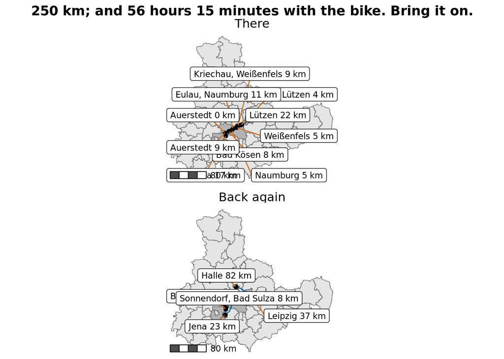

```r
ggplot() +
  geom_sf(data = municipalities_highlighted, aes(geometry = geometry, fill = visited)) +
  geom_sf(data = routes_geocoded, color = clrs[1]) +
  geom_sf(data = all_stops_unique) +
  geom_label_repel(
    data = routes_geocoded,
    aes(label = paste0(destination_location, " ", distance_text), geometry = destination_geometry),
    stat = "sf_coordinates", seed = 1234,
    size = 3, segment.color = clrs[3], min.segment.length = 0, max.overlaps = 20
  ) +
  annotation_scale(
    location = "bl", bar_cols = c("grey30", "white"),
    unit_category = "metric", text_family = "Overpass"
  ) +
  scale_fill_manual(values = c("grey90", "grey70"), guide = "none") +
  coord_sf(crs = st_crs("EPSG:25832")) +
  labs(title = glue("{total_distance}; and {total_time} with the bike. Bring it on.")) +
  theme_roadtrip() +
  facet_wrap(vars(direction), ncol = 1)
```

The more desired result is a map that shows each part of the trip in detail. First we need to extract the route for the specific part of the trip:

```r
route_day1 <- routes_geocoded %>%
  filter(direction == "There", part == 1 | part == 2)
```

And then send it into a pipeline that constructs the desired zoom level with a bounding box:

```r
bbox_nice <- route_day1 %>%
  st_bbox() %>%  # Extract the bounding box of the coordinates
  st_as_sfc() %>%  # Convert the bounding box matrix back to an sf object
  st_buffer(10) %>%  # Add 10 km to all sides
  st_transform("EPSG:25832") %>%  # Switch to UTM 32
  st_bbox()
```

The plot for the first part of the trip is now:

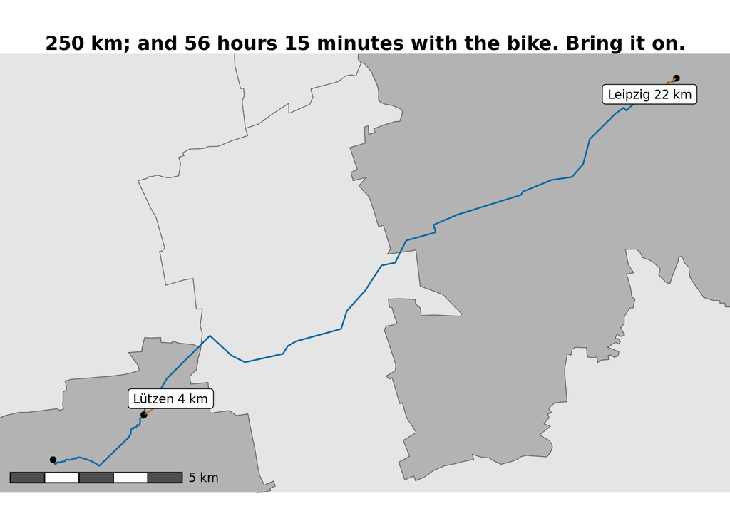

```r
ggplot() +
  geom_sf(data = municipalities_highlighted, aes(geometry = geometry, fill = visited)) +
  geom_sf(data = route_day1, color = clrs[1]) +
  geom_sf(data = all_stops_unique) +
  geom_label_repel(
    data = route_day1,
    aes(label = paste0(origin_location, " ", distance_text), geometry = origin_geometry),
    stat = "sf_coordinates", seed = 1234,
    size = 3, segment.color = clrs[3], min.segment.length = 0, max.overlaps = 20
  ) +
  annotation_scale(
    location = "bl", bar_cols = c("grey30", "white"),
    unit_category = "metric", text_family = "Overpass"
  ) +
  scale_fill_manual(values = c("grey90", "grey70"), guide = "none") +
  coord_sf(
    xlim = c(bbox_nice["xmin"], bbox_nice["xmax"]),
    ylim = c(bbox_nice["ymin"], bbox_nice["ymax"]),
    crs = st_crs("EPSG:25832")
  ) +
    labs(title = glue("{total_distance}; and {total_time} with the bike. Bring it on.")) +
  theme_roadtrip()
```

That is nice. We can now generalize the code, extract the routes to OSMAnd and use OSM data to display the route with actual mapping.

## Get OSM Tiles

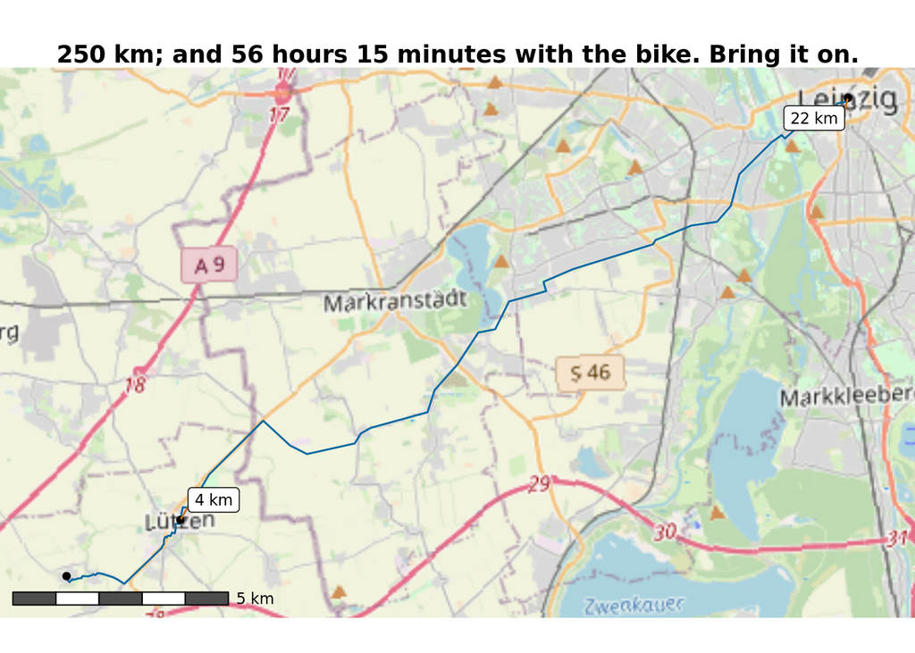

```r
# Get maptiles per bbox to save memory
dc <- get_tiles(bbox_nice, provider = "OpenStreetMap")
# And finally plot with ggplot2 + tidyterra

ggplot() +
  geom_spatraster_rgb(data = dc) +
  geom_sf(data = route_day1, color = clrs[1], size = 10) +
  geom_sf(data = all_stops_unique) +
  geom_label_repel(
    data = route_day1,
    aes(label = distance_text, geometry = origin_geometry),
    stat = "sf_coordinates", seed = 1234,
    size = 3, segment.color = clrs[3], min.segment.length = 0, max.overlaps = 20
  ) +
  annotation_scale(
    location = "bl", bar_cols = c("grey30", "white"),
    unit_category = "metric", text_family = "Overpass"
  ) +
  coord_sf(
    xlim = c(bbox_nice["xmin"], bbox_nice["xmax"]),
    ylim = c(bbox_nice["ymin"], bbox_nice["ymax"]),
    crs = st_crs("EPSG:25832")
  ) +
  labs(title = glue("{total_distance}; and {total_time} with the bike. Bring it on.")) +
  theme_roadtrip()
```